# RQ1 Step 4: Interpreting the models and answering RQ1

What drives the real cost per m² of new houses across districts?

while True: learn(), Group 8, STAT462

2026-11-15

```r
source(file.path(proj_root, "R", "utils_data.R"))
source(file.path(proj_root, "R", "utils_models.R"))
suppressPackageStartupMessages({
  library(knitr)
  library(ranger)
})
N_CORES <- max(1, parallel::detectCores() - 1)

rq1 <- readRDS(file.path(paths$processed, "rq1_model_data.rds"))
dat <- rq1 |>
  filter(year >= 1996, !ta %in% c("Chatham Islands Territory", "Kawerau District")) |>
  droplevels()
train <- dat |> filter(split == "train")
test  <- dat |> filter(split == "test")

# same response, features and folds as Step 3
Y <- "rel_log_cost_m2"
num_main <- c("rel_house_m2", "log_houses_n", "multiunit_share", "apt_share", "retire_share",
              "dwell_per_1000", "houses_yoy", "log_resid_alt_real", "log_nonres_real")
fsets <- list(drivers  = c(num_main, "region", "is_city"),
              district = c(num_main, "ta"))
folds <- make_time_folds(train$year)

s3 <- readRDS(file.path(paths$models_rq1, "rq1_step3_results.rds"))
s3$chosen |> select(set, model, best_settings, cv_rmse) |> kable(digits = 4, caption = "Models chosen in Step 3")
```

Models chosen in Step 3

| set | model | best_settings | cv_rmse |
| --- | --- | --- | --- |
| drivers | Random forest | mtry = 6, min.node.size = 20 | 0.0855 |
| district | Linear regression | (none) | 0.0814 |

# 1 Purpose

Step 3 chose two models with the one-standard-error rule:

- a random forest on the **drivers** set (measured features plus region and city), and
- linear regression on the **district** set (measured features plus the district itself).

Step 3 told us *which* features matter. This notebook asks *how* they matter and where the models fail:

1. How does the prediction change as each driver changes (partial dependence)?
2. Do the drivers mean the same thing when we compare districts with each other as when we follow one district over time?
3. How much of each district’s premium or discount is left once its drivers are accounted for?
4. Where and when are the test predictions wrong?
5. Would finer tuning have changed anything?

It ends with the answer to RQ1 and saves final models for later use (an app or poster).

The test set was already used once in Step 3. Nothing here changes a model because of test results: section 6 only describes the test errors, and section 7 uses cross-validation only.

# 2 Refit the models on all training years

We refit three models on 1996–2019 at the settings Step 3 chose. Linear regression on the drivers set is not one of the chosen models, but it gives a straight-line version of the same features to compare with the forest.

```r
rhs_of <- function(vars) paste(vars, collapse = " + ")
fml_of <- function(y, vars) as.formula(paste(y, "~", rhs_of(vars)))
best <- s3$best_settings

# random forest, drivers set (chosen)
b_rf <- best[["Random forest"]]$drivers
rf_drv <- ranger(fml_of(Y, fsets$drivers), data = train, num.trees = 500,
                 mtry = b_rf$mtry, min.node.size = b_rf$min.node.size,
                 num.threads = N_CORES, seed = 462)

# linear regression, drivers set (straight-line comparison) and district set (chosen)
fit_lm <- function(vars, data = train) list(fit = lm(fml_of(Y, vars), data = data), rhs = rhs_of(vars))
predict_lm <- function(m, newdata) as.numeric(predict(m$fit, newdata = newdata))

lm_drv  <- fit_lm(fsets$drivers)
lm_dist <- fit_lm(fsets$district)

# one prediction function per model, so the code below treats them alike
pred_funs <- list(
  "Random forest, drivers" = function(d) predict(rf_drv, d, num.threads = N_CORES)$predictions,
  "Linear, drivers"        = function(d) predict_lm(lm_drv, d),
  "Linear, district"       = function(d) predict_lm(lm_dist, d))

# check: the refitted models reproduce the Step 3 test RMSE
step3_rmse <- s3$test |> filter((model == "Random forest" & set == "drivers") |
                                 (model == "Linear regression" & set %in% c("drivers", "district"))) |>
  transmute(model = sub("Linear regression", "Linear", paste0(model, ", ", set)), step3 = test_rmse)
tibble(model = names(pred_funs),
       refit = map_dbl(pred_funs, \(f) reg_metrics(test[[Y]], f(test))$rmse)) |>
  left_join(step3_rmse, by = "model") |> kable(digits = 4, caption = "Test RMSE: refit vs Step 3")
```

Test RMSE: refit vs Step 3

| model | refit | step3 |
| --- | --- | --- |
| Random forest, drivers | 0.1134 | 0.1134 |
| Linear, drivers | 0.1162 | 0.1162 |
| Linear, district | 0.1066 | 0.1066 |

**Observation.** The refitted models give the same test RMSE as Step 3, so the plots below describe the models that were actually evaluated.

# 3 How each driver changes the prediction (partial dependence)

A **partial dependence plot** shows how a model’s average prediction changes as one feature moves, with all other features kept at their observed values. For each value *v* on a grid we set that feature to *v* in every training row, predict, and average. The result is the model’s view of that feature’s effect, averaged over everything else.

We use the 5th to 95th percentile of each feature, since the tails have few rows. Curves are centred at zero, so the y-axis reads as “% dearer or cheaper than the model’s average prediction”.

```r
# partial dependence of one feature: average prediction with the feature fixed at each grid value
partial_dependence <- function(pred_fun, data, var, grid) {
  map_dbl(grid, function(v) {
    data[[var]] <- v
    mean(pred_fun(data))
  })
}

pdp_vars <- c("log_resid_alt_real", "dwell_per_1000", "log_houses_n",
              "rel_house_m2", "log_nonres_real", "houses_yoy")

# labels, and how to show each feature's values in natural units in the panel titles
pdp_labels <- tribble(
  ~feature,             ~label,                                    ~fmt,
  "log_resid_alt_real", "Residential alterations ($ per quarter)", \(x) paste0("$", signif(expm1(x) / 1e6, 2), "m"),
  "dwell_per_1000",     "New dwellings per 1,000 residents",       \(x) as.character(round(x, 1)),
  "log_houses_n",       "New houses in the quarter",               \(x) as.character(round(exp(x))),
  "rel_house_m2",       "House size vs rest of NZ",                \(x) sprintf("%+.0f%%", 100 * (exp(x) - 1)),
  "log_nonres_real",    "New non-residential work ($ per quarter)", \(x) paste0("$", signif(expm1(x) / 1e6, 2), "m"),
  "houses_yoy",         "Houses vs same quarter last year",        \(x) sprintf("%+.0f%%", 100 * (exp(x) - 1))
)
pdp_probs <- seq(0.05, 0.95, by = 0.05)
```

```r
pdp <- expand_grid(model = names(pred_funs), feature = pdp_vars) |>
  pmap_dfr(function(model, feature) {
    grid <- quantile(train[[feature]], pdp_probs, names = FALSE)
    yhat <- partial_dependence(pred_funs[[model]], train, feature, grid)
    tibble(model, feature, pctile = pdp_probs, value = grid, yhat)
  }) |>
  group_by(model, feature) |>
  mutate(effect = yhat - mean(yhat)) |>
  ungroup()
```

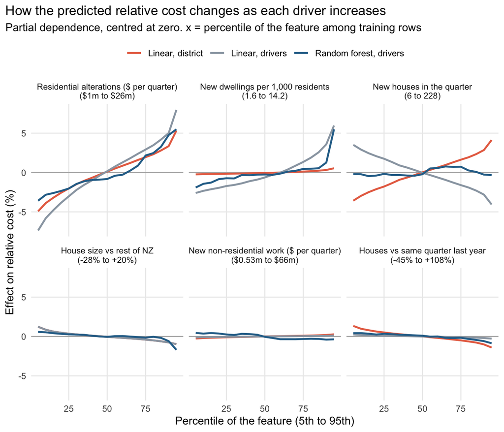

```r
# panel title: feature name and its 5th-95th percentile range in natural units
panel_titles <- pdp_labels |>
  mutate(range = map2_chr(feature, fmt, \(v, f) paste(f(quantile(train[[v]], c(0.05, 0.95))), collapse = " to ")),
         title = paste0(label, "\n(", range, ")"))

p_pdp <- pdp |>
  left_join(panel_titles |> select(feature, title), by = "feature") |>
  mutate(title = factor(title, levels = panel_titles$title)) |>
  ggplot(aes(100 * pctile, 100 * effect, colour = model)) +
  geom_hline(yintercept = 0, colour = "grey70") +
  geom_line(linewidth = 0.9) +
  facet_wrap(~title, ncol = 3) +
  scale_colour_manual(values = c("Random forest, drivers" = "#2a6f97", "Linear, drivers" = "#9aa5b1",
                                 "Linear, district" = "#e76f51")) +
  labs(title = "How the predicted relative cost changes as each driver increases",
       subtitle = "Partial dependence, centred at zero. x = percentile of the feature among training rows",
       x = "Percentile of the feature (5th to 95th)", y = "Effect on relative cost (%)", colour = NULL) +
  theme(legend.position = "top", strip.text = element_text(size = 8.5))
save_fig(p_pdp, "fig24_partial_dependence", height = 6, width = 9)
```

```r
# size of each effect: change in prediction from the 10th to the 90th percentile of the feature
effect_10_90 <- expand_grid(model = names(pred_funs), feature = pdp_vars) |>
  pmap_dfr(function(model, feature) {
    q <- quantile(train[[feature]], c(0.1, 0.9), names = FALSE)
    change <- diff(partial_dependence(pred_funs[[model]], train, feature, q))
    tibble(model, feature, change)
  }) |>
  mutate(change_pct = 100 * (exp(change) - 1)) |>
  select(-change) |>
  pivot_wider(names_from = model, values_from = change_pct) |>
  left_join(pdp_labels |> select(feature, label), by = "feature") |>
  relocate(label, .after = feature)
save_tab(effect_10_90, "t12_effect_sizes") |>
  kable(digits = 1, caption = "Change in predicted relative cost (%) from the 10th to the 90th percentile of each feature")
```

Change in predicted relative cost (%) from the 10th to the 90th percentile of each feature

| feature | label | Random forest, drivers | Linear, drivers | Linear, district |
| --- | --- | --- | --- | --- |
| log_resid_alt_real | Residential alterations ($ per quarter) | 7.9 | 11.4 | 7.5 |
| dwell_per_1000 | New dwellings per 1,000 residents | 2.7 | 6.1 | 0.5 |
| log_houses_n | New houses in the quarter | 0.0 | -5.6 | 6.0 |
| rel_house_m2 | House size vs rest of NZ | -1.1 | -1.6 | -1.6 |
| log_nonres_real | New non-residential work ($ per quarter) | -0.8 | 0.2 | 0.4 |
| houses_yoy | Houses vs same quarter last year | -1.0 | -0.4 | -2.0 |

**Observation.** The table gives the change from a typical low value (10th percentile) to a typical high value (90th percentile) of each feature.

Most effects are a few percent, small next to the ±15–20% gaps between the dearest and cheapest districts. The measured drivers shift a district’s cost at the margin. They do not explain most of the gap between places.

## 3.1 Do two drivers work together? (interaction)

The tree in Step 3 split first on alteration spending and then on growth, which suggests the two act together. A two-way partial dependence plot fixes both features on a grid and averages the forest’s predictions.

```r
g_alt  <- quantile(train$log_resid_alt_real, seq(0.05, 0.95, length.out = 10), names = FALSE)
g_grow <- quantile(train$dwell_per_1000,     seq(0.05, 0.95, length.out = 10), names = FALSE)
pdp2 <- expand_grid(alt = g_alt, grow = g_grow) |>
  mutate(yhat = map2_dbl(alt, grow, function(a, g) {
    d <- train; d$log_resid_alt_real <- a; d$dwell_per_1000 <- g
    mean(pred_funs[["Random forest, drivers"]](d))
  }))
```

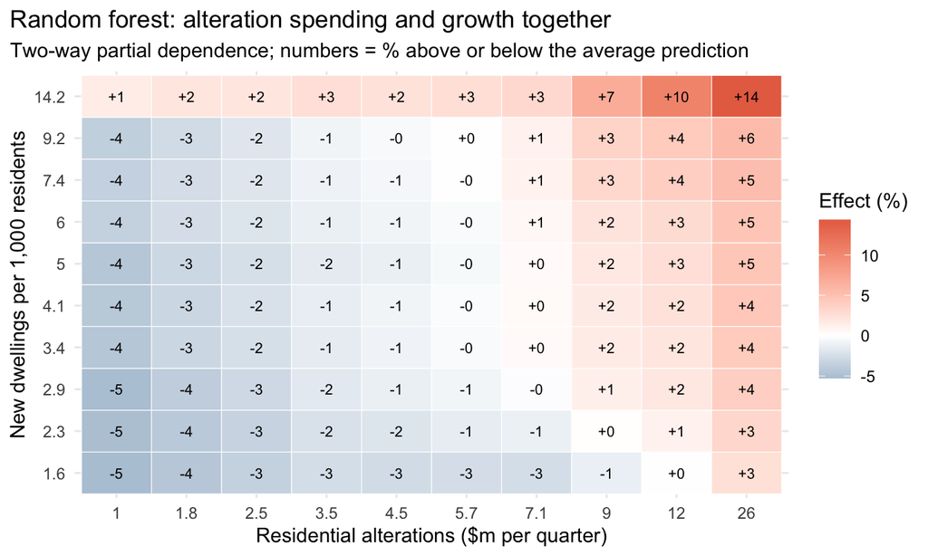

```r
p_pdp2 <- pdp2 |>
  mutate(effect = 100 * (yhat - mean(yhat)),
         alt_m = factor(signif(expm1(alt) / 1e6, 2)), grow = factor(round(grow, 1))) |>
  ggplot(aes(alt_m, grow, fill = effect)) +
  geom_tile(colour = "white") +
  geom_text(aes(label = sprintf("%+.0f", effect)), size = 2.8) +
  scale_fill_gradient2(low = "#2a6f97", mid = "white", high = "#e76f51", midpoint = 0) +
  labs(title = "Random forest: alteration spending and growth together",
       subtitle = "Two-way partial dependence; numbers = % above or below the average prediction",
       x = "Residential alterations ($m per quarter)", y = "New dwellings per 1,000 residents",
       fill = "Effect (%)")
save_fig(p_pdp2, "fig25_interaction_alterations_growth", height = 4.2, width = 8)
```

# 4 Comparing districts versus following one district over time

The drivers set has no district variable, so its coefficients mix two comparisons. One is *between* districts (is a busy district dearer than a quiet one?). The other is *within* a district over time (is a district dearer in its busy quarters?). Once the district is in the model, every district gets its own level, and the remaining coefficients describe only the within-district comparison.

Comparing the standardised linear-regression coefficients of the two sets shows which drivers change meaning.

```r
std_coef <- function(m, data) {
  b <- coef(m$fit)[num_main]
  tibble(feature = num_main, coef = b * map_dbl(num_main, \(v) sd(data[[v]])))
}
within_between <- std_coef(lm_drv, train) |> rename(`drivers set (between + within)` = coef) |>
  left_join(std_coef(lm_dist, train) |> rename(`district set (within only)` = coef), by = "feature") |>
  mutate(`sign flips` = sign(`drivers set (between + within)`) != sign(`district set (within only)`)) |>
  arrange(desc(abs(`drivers set (between + within)`)))
save_tab(within_between, "t13_within_between") |>
  kable(digits = 4, caption = "Linear regression, standardised coefficients (log points per 1 SD of the feature)")
```

Linear regression, standardised coefficients (log points per 1 SD of the feature)

| feature | drivers set (between + within) | district set (within only) | sign flips |
| --- | --- | --- | --- |
| log_resid_alt_real | 0.0491 | 0.0328 | FALSE |
| dwell_per_1000 | 0.0313 | 0.0028 | FALSE |
| log_houses_n | -0.0234 | 0.0238 | TRUE |
| rel_house_m2 | -0.0068 | -0.0068 | FALSE |
| houses_yoy | -0.0016 | -0.0084 | FALSE |
| apt_share | 0.0015 | -0.0010 | TRUE |
| multiunit_share | -0.0008 | 0.0017 | TRUE |
| log_nonres_real | 0.0008 | 0.0017 | FALSE |
| retire_share | 0.0007 | -0.0013 | TRUE |

**Observation.** Two drivers change meaning once the district is held fixed.

- **Number of new houses** flips sign. *Between* districts, places that build many houses are cheaper per m² than places with the same alteration spending and growth that build fewer (volume builders, large subdivisions such as Selwyn). On its own, without alteration spending in the model, the number of houses has a small positive link with cost, because both measure how big a district’s building market is (correlation 0.84). *Within* a district, its busier quarters are dearer (more demand for the same builders and materials). The drivers-set model mixes the two, and the between-district pattern dominates. This also explains the flat forest curve in section 3: the forest combines the two opposite patterns.
- **Dwellings per 1,000 residents** shrinks from 0.031 to 0.003. Fast-growing *districts* are dearer, but a district is not much dearer in its own fast-growth years. The growth effect is mostly a difference between places.

Alteration spending keeps the same sign and a similar size in both sets, so it holds both between and within districts. The mix shares (apartments, retirement units, multi-unit) are close to zero in both, and their sign flips are noise.

# 5 How much of each district’s premium do the drivers explain?

In the district-set linear model, each district has its own coefficient. That coefficient is the part of the district’s relative cost that its measured drivers do **not** explain. We compare it with the district’s raw average relative cost over 1996–2019. Both are centred on the average district so they are on the same footing. There is no shrinkage, so the premiums of small districts, estimated from few quarters, are the noisiest.

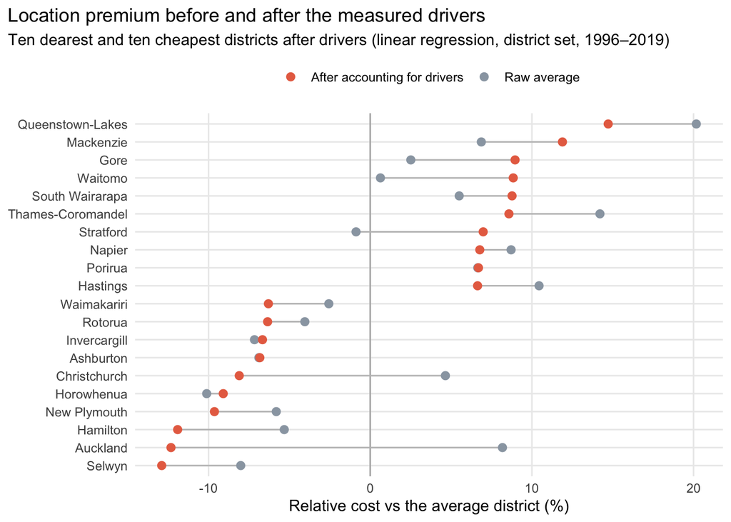

```r
b_dist <- coef(lm_dist$fit)
ta_levels <- levels(train$ta)
premium <- tibble(ta = ta_levels,
                  after = c(0, b_dist[paste0("ta", ta_levels[-1])])) |>   # first level is the reference (0)
  left_join(train |> group_by(ta) |> summarise(raw = mean(rel_log_cost_m2), quarters = n()) |>
              mutate(ta = as.character(ta)), by = "ta") |>
  mutate(after = after - mean(after), raw = raw - mean(raw),
         explained = raw - after)

premium_show <- bind_rows(premium |> slice_max(after, n = 10), premium |> slice_min(after, n = 10)) |>
  mutate(name = fct_reorder(str_remove(ta, " District| City"), after))

p_prem <- premium_show |>
  pivot_longer(c(raw, after), names_to = "measure", values_to = "value") |>
  mutate(measure = recode(measure, raw = "Raw average", after = "After accounting for drivers")) |>
  ggplot(aes(100 * value, name)) +
  geom_vline(xintercept = 0, colour = "grey70") +
  geom_line(aes(group = name), colour = "grey75") +
  geom_point(aes(colour = measure), size = 2.3) +
  scale_colour_manual(values = c("Raw average" = "#9aa5b1", "After accounting for drivers" = "#e76f51")) +
  labs(title = "Location premium before and after the measured drivers",
       subtitle = "Ten dearest and ten cheapest districts after drivers (linear regression, district set, 1996–2019)",
       x = "Relative cost vs the average district (%)", y = NULL, colour = NULL) +
  theme(legend.position = "top")
save_fig(p_prem, "fig26_district_premium", height = 5.5, width = 8)
```

```r
c(sd_raw = sd(premium$raw), sd_after = sd(premium$after),
  share_of_spread_left = var(premium$after) / var(premium$raw))
```

```
##               sd_raw             sd_after share_of_spread_left
##           0.06438636           0.05950927           0.85424316
```

**Observation.** The measured drivers explain only part of why some districts are dear.

- The spread of district premiums falls only from 6.4% to 6.0% (standard deviation, log scale). About 15% of the variance between district averages is explained by the drivers; the rest is location itself.
- **Queenstown-Lakes** stays the dearest district even after its drivers (about +15% vs the average district). **Thames-Coromandel** and **Wellington City** lose about half their premium: their high alteration spending accounts for that part.
- **Auckland and Christchurch** move from dearer than average to cheaper than their drivers predict. They have the largest alteration and non-residential spending in the country, so the model expects them to be very dear, and they are less dear than that. This shows a weakness in our features: the activity measures are **total dollars**, so they partly measure district *size*. Per-resident versions would separate size from wealth (see the limitations in section 8).
- **Selwyn, Hamilton and Horowhenua** remain cheap after their drivers. These are flat, easy-to-build greenfield markets with volume builders, which our features do not capture directly.

# 6 Where are the test predictions wrong?

We use the test predictions saved in Step 3 for the two chosen models and the district-mean baseline. A residual here is *predicted minus actual*, so a negative residual means the model under-predicted.

```r
tp <- s3$test_predictions |>
  mutate(model = paste0(model, ", ", set)) |>
  filter(model %in% c("Random forest, drivers", "Linear regression, district", "District mean, none")) |>
  mutate(model = recode(model, "District mean, none" = "District mean (baseline)",
                        "Linear regression, district" = "Linear, district"),
         resid = pred - obs) |>
  left_join(test |> mutate(row = row_number()) |> select(row, houses_n), by = "row")
```

## 6.1 By year

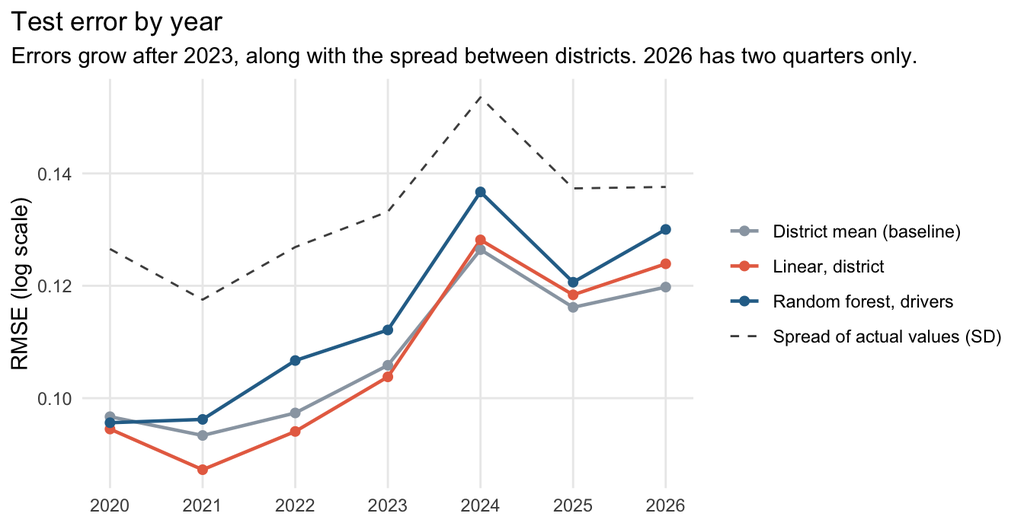

```r
by_year <- tp |>
  group_by(model, year) |>
  summarise(rmse = sqrt(mean(resid^2)), bias = mean(resid), .groups = "drop") |>
  left_join(test |> group_by(year) |> summarise(spread = sd(.data[[Y]])), by = "year")

p_year <- by_year |>
  ggplot(aes(year, rmse, colour = model)) +
  geom_line(linewidth = 0.8) + geom_point(size = 1.8) +
  geom_line(aes(y = spread, colour = "Spread of actual values (SD)"), linetype = 2) +
  scale_colour_manual(values = c("Random forest, drivers" = "#2a6f97", "Linear, district" = "#e76f51",
                                 "District mean (baseline)" = "#9aa5b1",
                                 "Spread of actual values (SD)" = "grey30")) +
  scale_x_continuous(breaks = 2020:2026) +
  labs(title = "Test error by year",
       subtitle = "Errors grow after 2023, along with the spread between districts. 2026 has two quarters only.",
       x = NULL, y = "RMSE (log scale)", colour = NULL) +
  theme(legend.position = "right")
save_fig(p_year, "fig27_test_error_by_year", height = 3.6, width = 8.5)
```

```r
by_year |> select(model, year, rmse, bias) |>
  pivot_wider(names_from = model, values_from = c(rmse, bias)) |> kable(digits = 3)
```

| year | rmse_District mean (baseline) | rmse_Linear, district | rmse_Random forest, drivers | bias_District mean (baseline) | bias_Linear, district | bias_Random forest, drivers |
| --- | --- | --- | --- | --- | --- | --- |
| 2020 | 0.097 | 0.095 | 0.096 | -0.024 | -0.018 | -0.018 |
| 2021 | 0.093 | 0.087 | 0.096 | -0.038 | -0.024 | -0.023 |
| 2022 | 0.097 | 0.094 | 0.107 | -0.026 | -0.009 | -0.002 |
| 2023 | 0.106 | 0.104 | 0.112 | -0.026 | -0.015 | -0.011 |
| 2024 | 0.126 | 0.128 | 0.137 | -0.026 | -0.026 | -0.027 |
| 2025 | 0.116 | 0.118 | 0.121 | -0.039 | -0.043 | -0.039 |
| 2026 | 0.120 | 0.124 | 0.130 | -0.042 | -0.047 | -0.041 |

**Observation.** All three models have their smallest errors in 2020–2022 and their largest in 2024, the year the spread between districts peaked (dashed line). The linear model beats the district-mean baseline in 2020–2023 and falls slightly behind it in 2024–2026. The relationships learned before 2020 held for a few years and then started to drift.

Every model under-predicts on average (negative bias, about −2% early on and −4% by 2025–26). The average relative cost of the modelled districts rose after 2020: smaller districts became dearer compared with the large centres that dominate the “rest of NZ” average. A model trained on 1996–2019 has no way to know this.

## 6.2 By number of houses

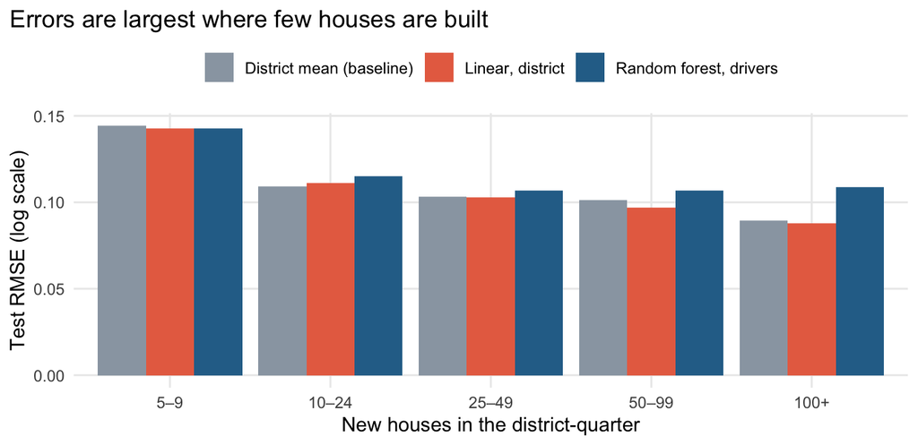

```r
by_size <- tp |>
  mutate(size = cut(houses_n, c(4, 9, 24, 49, 99, Inf),
                    labels = c("5–9", "10–24", "25–49", "50–99", "100+"))) |>
  group_by(model, size) |>
  summarise(rows = n(), rmse = sqrt(mean(resid^2)), .groups = "drop")

p_size <- ggplot(by_size, aes(size, rmse, fill = model)) +
  geom_col(position = "dodge") +
  scale_fill_manual(values = c("Random forest, drivers" = "#2a6f97", "Linear, district" = "#e76f51",
                               "District mean (baseline)" = "#9aa5b1")) +
  labs(title = "Errors are largest where few houses are built",
       x = "New houses in the district-quarter", y = "Test RMSE (log scale)", fill = NULL) +
  theme(legend.position = "top")
save_fig(p_size, "fig28_test_error_by_size", height = 3.4)
```

```r
by_size |> filter(model == "Linear, district") |> select(size, rows, rmse) |> kable(digits = 3)
```

| size | rows | rmse |
| --- | --- | --- |
| 5–9 | 167 | 0.143 |
| 10–24 | 399 | 0.111 |
| 25–49 | 450 | 0.103 |
| 50–99 | 354 | 0.097 |
| 100+ | 238 | 0.088 |

**Observation.** Error falls steadily as the number of houses rises: RMSE is about 0.14 for district-quarters with 5–9 houses and 0.09 for those with 100 or more. This is the same funnel as in Step 1: with few houses, one unusual consent moves the quarter’s $/m². Part of the test error is therefore noise in the response that no model could remove.

## 6.3 By district

```r
by_district <- tp |>
  filter(model == "Linear, district") |>
  group_by(ta) |>
  summarise(quarters = n(), median_houses = median(houses_n),
            mean_resid = mean(resid), rmse = sqrt(mean(resid^2)), .groups = "drop") |>
  arrange(desc(rmse))
save_tab(by_district, "t14_test_error_by_district") |>
  head(10) |>
  kable(digits = 3, caption = "Linear regression (district set): ten districts with the largest test RMSE")
```

Linear regression (district set): ten districts with the largest test RMSE

| ta | quarters | median_houses | mean_resid | rmse |
| --- | --- | --- | --- | --- |
| Opotiki District | 21 | 7.0 | -0.130 | 0.267 |
| Wairoa District | 8 | 6.0 | -0.181 | 0.215 |
| Kaipara District | 26 | 33.5 | -0.146 | 0.163 |
| Gisborne District | 26 | 20.5 | -0.031 | 0.156 |
| Thames-Coromandel District | 26 | 54.5 | -0.133 | 0.155 |
| Otorohanga District | 21 | 9.0 | 0.030 | 0.149 |
| Waimakariri District | 26 | 151.5 | 0.145 | 0.148 |
| Western Bay of Plenty District | 26 | 64.0 | -0.122 | 0.143 |
| Waimate District | 15 | 7.0 | 0.004 | 0.140 |
| Queenstown-Lakes District | 26 | 143.5 | -0.123 | 0.136 |

**Observation.** Two groups stand out.

- **Small districts** (Ōpōtiki, Wairoa, Otorohanga, Waimate) with a median of 6–9 houses a quarter. Their errors are mostly noise, as the previous section showed.
- **Larger districts that changed after 2020.** Coastal and lifestyle districts (Kaipara, Thames-Coromandel, Western Bay of Plenty, Queenstown-Lakes) were under-predicted by 12–15%: they became even dearer relative to the rest of NZ. Waimakariri, a volume-building district north of Christchurch, was over-predicted by about 14%: it became cheaper. These look like real shifts in the market after COVID (more demand for lifestyle and holiday areas, more volume building in Canterbury) rather than model errors that better tuning could fix.

# 7 Would finer tuning change anything?

Step 3 searched a coarse grid. Here we search a finer grid around the forest’s chosen settings, using the same training folds. Linear regression has no settings to refine. We only look at CV scores, because the test set has been used.

```r
fp_rf <- function(vars, y) function(tr, nw, p)
  predict(ranger(fml_of(y, vars), data = tr, num.trees = 500, mtry = p$mtry,
                 min.node.size = p$min.node.size, num.threads = N_CORES, seed = 462), data = nw)$predictions
rf_fine <- cv_tune(fp_rf(fsets$drivers, Y),
                   expand_grid(mtry = 5:8, min.node.size = c(10, 15, 20, 30)),
                   train, folds, Y)
```

```r
rf_step3 <- s3$cv |> filter(model == "Random forest", set == "drivers")
rf_fine$summary |> head(5) |> select(mtry, min.node.size, cv_rmse, cv_rmse_sd) |>
  kable(digits = 4, caption = "Finer forest grid, best five settings")
```

Finer forest grid, best five settings

| mtry | min.node.size | cv_rmse | cv_rmse_sd |
| --- | --- | --- | --- |
| 6 | 20 | 0.0855 | 0.0056 |
| 6 | 10 | 0.0855 | 0.0056 |
| 5 | 20 | 0.0855 | 0.0052 |
| 6 | 15 | 0.0855 | 0.0056 |
| 5 | 15 | 0.0856 | 0.0053 |

```r
c(step3_cv_rmse = rf_step3$cv_rmse, step3_se = rf_step3$cv_rmse_se,
  refined_cv_rmse = rf_fine$best$cv_rmse,
  gain = rf_step3$cv_rmse - rf_fine$best$cv_rmse)
```

```
##   step3_cv_rmse        step3_se refined_cv_rmse            gain
##     0.085486966     0.002794983     0.085486966     0.000000000
```

**Observation.** The finer grid picks the same setting as Step 3 (`mtry` = 6, `min.node.size` = 20), and the top five settings are within 0.0001 of each other, far less than one standard error (0.0028). The forest is not sensitive to its settings near the optimum, so further tuning would not change any conclusion. We keep the Step 3 models.

# 8 Answer to RQ1

**Question.** What drives the real cost per m² of new houses across New Zealand districts?

**Short answer.** Location matters most. The measured drivers explain a modest part of it, led by how much a district spends on renovating existing homes and how fast it is growing.

| Driver | Direction | Size (10th → 90th percentile) | Evidence |
| --- | --- | --- | --- |
| Residential alteration spending | dearer | about +8% to +11% | top feature in all three importance methods; same sign between and within districts |
| Region (broad location) | varies | up to about ±10% | second in importance in Step 3 |
| Dwellings per 1,000 residents | dearer | about +3% to +6%, plus about +4% more in the fastest-growing 10% | differs *between* districts, little *within* |
| Number of new houses | cheaper between districts (for the same alteration spending), dearer within | about ±5–6% | volume markets are cheaper; busy quarters are dearer |
| Relative house size | slightly cheaper | about −1% to −2% | fixed costs spread over more floor area |
| Dwelling mix (apartments, townhouses, retirement) | none detected | under 1% | near zero in every model |

**How well can we predict it?**

- With the measured drivers and broad region only, the best models (random forest, XGBoost, SVM) explain about a third of the variation in relative cost (CV R² ≈ 0.32). That is about as much as knowing the district name alone.
- With the district added, linear regression explains about 38% in cross-validation and predicts 2020–2026 within about 8% (MAPE), marginally better than each district’s historical average.
- About 85% of the variation between district averages is not explained by our measured drivers. It sits in location itself: land, terrain, local labour markets, and the kind of house each place builds.

**Limitations.**

- Our activity features are total dollars, so they partly measure district size. Per-resident versions (alterations per resident, non-residential per resident) would be cleaner. Population estimates were not in this release.
- We do not observe land prices, house quality or specification, or builder type, which are the most likely sources of the unexplained location premium.
- The data are observational. “Dearer where alteration spending is high” is an association, not a cause; both probably reflect wealthier markets.
- Relationships drifted after 2023 (section 6.1), so a model for current use should be retrained regularly.

# 9 Save final models

For later use (an app or the poster), we refit the two chosen models on **all** modelled rows from 1996 to 2026Q2. The test years have done their job, and the final models should learn from the most recent data. We also save the latest values of every feature for each district, which an app can use as default inputs, and the latest “rest of NZ” $/m², which turns a relative prediction back into dollars.

```r
final_rf <- ranger(fml_of(Y, fsets$drivers), data = dat, num.trees = 500,
                   mtry = b_rf$mtry, min.node.size = b_rf$min.node.size,
                   num.threads = N_CORES, seed = 462)
final_lm <- fit_lm(fsets$district, data = dat)

# latest four quarters for each district: average feature values and the rest-of-NZ $/m²
latest <- dat |>
  group_by(ta) |>
  slice_max(t_index, n = 4) |>
  summarise(region = first(region), is_city = first(is_city),
            across(all_of(num_main), mean),
            loo_cost_m2 = mean(loo_cost_m2), real_cost_m2 = mean(real_cost_m2),
            last_quarter = max(as.character(yq)), .groups = "drop")

saveRDS(list(rf_drivers = final_rf, lm_district = final_lm,
             features = fsets, num_main = num_main, response = Y,
             factor_levels = list(ta = levels(dat$ta), region = levels(dat$region)),
             latest = latest, trained_on = "1996Q1-2026Q2, districts with >= 5 new houses"),
        file.path(paths$models_rq1, "rq1_final_models.rds"))
file.size(file.path(paths$models_rq1, "rq1_final_models.rds")) / 2^20   # MB
```

```
## [1] 11.6133
```

# 10 Appendix: helper functions

This notebook uses helper functions from `R/utils_data.R` and `R/utils_models.R`, printed here so the document is complete on its own.

```r
# =============================================================================
# R/utils_data.R
# Shared helpers for reading and reshaping Stats NZ data.
# Source this from any Rmd after the project root has been set:
#   source(file.path(proj_root, "R", "utils_data.R"))
# =============================================================================

suppressPackageStartupMessages({
  library(data.table)
  library(tidyverse)
})

# ---- Paths (all relative to the project root) -------------------------------
paths <- list(
  raw_extracted = "data/raw/extracted",
  raw_cgpi      = "data/raw/external/cgpi",
  reference     = "data/reference",
  processed     = "data/processed",
  fig_rq1       = "outputs/figures/rq1",
  tab_rq1       = "outputs/tables/rq1",
  fig_rq2       = "outputs/figures/rq2",
  tab_rq2       = "outputs/tables/rq2"
)

# ---- Reading Stats NZ "Infoshare" long-format CSVs --------------------------
# Every Infoshare file has one row per (series x period). We read only the
# columns that carry information and give them short working names.
#
# Notes
# * `Period` MUST be read as text: as a number, "2025.10" becomes 2025.1,
#   which is indistinguishable from January.
# * integer64 is turned off so that large dollar values come back as doubles
#   (integer64 silently overflows on division).
read_infoshare <- function(file,
                           dir = paths$raw_extracted,
                           keep_status = FALSE) {
  cols <- c("Series_reference", "Period", "Data_value",
            "Series_title_1", "Series_title_2",
            "Series_title_3", "Series_title_4", "Series_title_5")
  if (keep_status) cols <- c(cols, "Status")

  dt <- fread(file.path(dir, file),
              select      = cols,
              colClasses  = list(character = "Period"),
              integer64   = "double",
              na.strings  = c("", "NA"),
              showProgress = FALSE)

  as_tibble(dt) |>
    rename(series  = Series_reference,
           period  = Period,
           value   = Data_value,
           area    = Series_title_1,
           btype   = Series_title_2,
           work    = Series_title_3,
           measure = Series_title_4,
           adjust  = Series_title_5)   # Actual / Seasonally adjusted / Trend (regional files only)
}

# ---- Period helpers ----------------------------------------------------------
# "YYYY.MM" -> integer year / month / calendar quarter
period_year    <- function(p) as.integer(substr(p, 1, 4))
period_month   <- function(p) as.integer(substr(p, 6, 7))
month_quarter  <- function(m) (m - 1L) %/% 3L + 1L

# Label like "2019Q3"
yq_label <- function(year, quarter) paste0(year, "Q", quarter)

# Sequential quarter index (1990Q1 = 1) - handy as a numeric time trend
yq_index <- function(year, quarter) (year - 1990L) * 4L + quarter

# ---- GST ---------------------------------------------------------------------
# Consent values are GST-inclusive. GST was 12.5% from 1 Jul 1989 to
# 30 Sep 2010 and 15% from 1 Oct 2010. Every month in our data is >= 1990,
# so only these two rates apply. Quarter boundaries line up with the change
# (2010Q4 starts on 1 Oct 2010), so a quarter-level rule is exact.
gst_rate <- function(year, quarter) {
  if_else(yq_index(year, quarter) >= yq_index(2010L, 4L), 0.15, 0.125)
}

# ---- Small display helpers ---------------------------------------------------
fmt_int <- function(x) format(round(x), big.mark = ",", scientific = FALSE)
fmt_dol <- function(x) paste0("$", fmt_int(x))
fmt_pct <- function(x, d = 1) paste0(format(round(100 * x, d), nsmall = d), "%")

# ---- Figures -----------------------------------------------------------------
theme_set(theme_minimal(base_size = 11) +
            theme(plot.title.position = "plot",
                  panel.grid.minor = element_blank()))

# Save a ggplot as PNG (for the report) and return it (so it also shows in the Rmd)
save_fig <- function(p, name, dir = paths$fig_rq1, width = 7, height = 4.2) {
  dir.create(dir, recursive = TRUE, showWarnings = FALSE)
  ggsave(file.path(dir, paste0(name, ".png")), p,
         width = width, height = height, dpi = 200, bg = "white")
  p
}

# Save a table as CSV (for the report) and return it
save_tab <- function(df, name, dir = paths$tab_rq1) {
  dir.create(dir, recursive = TRUE, showWarnings = FALSE)
  write_csv(df, file.path(dir, paste0(name, ".csv")))
  df
}
```

```r
# =============================================================================
# R/utils_models.R
# Shared helpers for fitting, tuning and comparing models (Step 3 onwards).
# Source AFTER utils_data.R:
#   source(file.path(proj_root, "R", "utils_data.R"))
#   source(file.path(proj_root, "R", "utils_models.R"))
#
# The idea: every model is written as ONE function
#     fit_predict(train_df, new_df, params)  ->  predictions for new_df
# and the same tuning / scoring code is used for all of them. That way every
# model is judged on exactly the same folds with exactly the same metrics.
# =============================================================================

paths$models_rq1 <- "outputs/models/rq1"

# ---- Metrics -----------------------------------------------------------------
# obs, pred: numeric vectors on the LOG scale.
#   rmse  root mean squared error   (penalises big misses more)
#   mae   mean absolute error       (typical miss)
#   r2    1 - SSE / SST             (share of variance explained, on these rows)
# On the log scale an error of 0.10 is roughly a 10% miss in $/m².
reg_metrics <- function(obs, pred) {
  e <- pred - obs
  tibble(rmse = sqrt(mean(e^2)),
         mae  = mean(abs(e)),
         r2   = 1 - sum(e^2) / sum((obs - mean(obs))^2))
}

# MAPE on the dollar scale: mean |predicted - actual| / actual
mape <- function(obs_dollars, pred_dollars) mean(abs(pred_dollars - obs_dollars) / obs_dollars)

# ---- Time-ordered cross-validation folds ------------------------------------
# "Forward-chaining" (rolling-origin) CV: each fold trains on all years BEFORE a
# validation block and validates on that block. This mimics the real task
# (learn from the past, predict the future) and never lets a model peek ahead.
#   years        : the year of every training row
#   valid_blocks : list of year vectors, one per fold
# Returns a named list of folds, each with $train and $valid row numbers.
make_time_folds <- function(years,
                            valid_blocks = list(2012:2013, 2014:2015, 2016:2017, 2018:2019)) {
  folds <- lapply(valid_blocks, function(b)
    list(train = which(years < min(b)), valid = which(years %in% b)))
  names(folds) <- vapply(valid_blocks, function(b) paste0("valid ", min(b), "-", max(b)), "")
  folds
}

# ---- Generic tuner -----------------------------------------------------------
# fit_predict(train_df, new_df, params) must return either
#   * a numeric vector (one prediction per row of new_df), or
#   * a matrix with one column per value of an "inner" setting that one fit can
#     produce for free (lambda for glmnet, number of rounds for xgboost). The
#     column names hold that setting's value and `inner` names it.
#     The values are rounded to 6 significant figures before grouping: going
#     through column names (text) can change the last digits, and then the
#     same lambda would not match across folds.
# grid: data frame, one row per combination of settings to try.
# Returns list(folds = per-fold scores, summary = mean score per setting,
#              best = the setting with the lowest mean RMSE).
cv_tune <- function(fit_predict, grid, data, folds, response, inner = NULL) {
  grid <- as_tibble(grid)
  if (nrow(grid) == 0) grid <- tibble(.dummy = 1)

  per_fold <- map_dfr(seq_len(nrow(grid)), function(g) {
    params <- as.list(grid[g, , drop = FALSE])
    map_dfr(names(folds), function(fn) {
      f    <- folds[[fn]]
      pred <- fit_predict(data[f$train, ], data[f$valid, ], params)
      pred <- as.matrix(pred)
      if (is.null(colnames(pred))) colnames(pred) <- "0"
      obs  <- data[[response]][f$valid]
      map_dfr(colnames(pred), function(cn)
        reg_metrics(obs, pred[, cn]) |>
          mutate(config = g, inner_value = signif(as.numeric(cn), 6), fold = fn, n_valid = length(obs)))
    })
  })

  summary <- per_fold |>
    group_by(config, inner_value) |>
    summarise(cv_rmse = mean(rmse), cv_rmse_sd = sd(rmse),
              cv_mae = mean(mae), cv_r2 = mean(r2), .groups = "drop") |>
    left_join(grid |> mutate(config = row_number()), by = "config") |>
    select(-any_of(".dummy")) |>
    arrange(cv_rmse)
  if (!is.null(inner)) summary <- rename(summary, !!inner := inner_value)
  else summary <- select(summary, -inner_value)

  list(folds = per_fold, summary = summary, best = summary[1, ])
}

# ---- Design matrix with a fixed set of columns ------------------------------
# glmnet, xgboost and svm need a numeric matrix, not a data frame with factors.
# model.matrix() turns each factor into 0/1 "dummy" columns. Because our factors
# carry ALL their levels, train and test matrices always get the same columns.
make_x <- function(df, rhs) {
  model.matrix(as.formula(paste("~", rhs)), data = df)[, -1, drop = FALSE]  # drop intercept
}

# ---- Timing helper -----------------------------------------------------------
# Runs an expression and returns its value with the elapsed seconds attached.
timed <- function(expr) {
  t0  <- Sys.time()
  out <- force(expr)
  attr(out, "seconds") <- as.numeric(difftime(Sys.time(), t0, units = "secs"))
  out
}

# ---- Summarising tuning results ---------------------------------------------
# res_by_set: a named list (one element per feature set) of cv_tune() results.
# Returns one row per feature set: the best setting found and its CV scores.
settings_text <- function(best) {
  b <- best |> select(-any_of(c("config", "cv_rmse", "cv_rmse_sd", "cv_mae", "cv_r2")))
  if (ncol(b) == 0) return("(none)")
  paste(names(b), signif(unlist(b), 3), sep = " = ", collapse = ", ")
}

summarise_tuning <- function(res_by_set, model) {
  imap_dfr(res_by_set, function(r, set)
    tibble(model = model, set = set,
           cv_rmse = r$best$cv_rmse, cv_rmse_se = r$best$cv_rmse_sd / sqrt(n_distinct(r$folds$fold)),
           cv_mae = r$best$cv_mae, cv_r2 = r$best$cv_r2,
           n_settings_tried = nrow(r$summary),
           best_settings = settings_text(r$best),
           seconds = round(attr(r, "seconds"), 1)))
}

# ---- Refit the best setting on ALL training rows and predict new rows -------
# factory(vars, y) returns a fit_predict function (see cv_tune). For models with
# an inner setting, the prediction column closest to the chosen value is kept.
refit_predict <- function(factory, res_by_set, sets, y, train_df, new_df, inner = NULL) {
  imap(sets, function(vars, set) {
    best <- res_by_set[[set]]$best
    pred <- as.matrix(factory(vars, y)(train_df, new_df, as.list(best)))
    if (!is.null(inner))
      pred <- pred[, which.min(abs(as.numeric(colnames(pred)) - best[[inner]])), drop = FALSE]
    as.numeric(pred)
  })
}
```